# ATP Analysis and Prediction

### 4.1.4 Prediction

```r
#Cleaning the predict database
ATP_matches_predict$winner_hand <- as.factor(ATP_matches_predict$winner_hand)
ATP_matches_predict <- ATP_matches_predict[ATP_matches_predict$winner_hand != "U", ]
```

```r
#PREDICT
ATP_matches_predict$predicted_ace <- predict(poisson_model, newdata = ATP_matches_predict)+1

error = ATP_matches_predict$w_ace-ATP_matches_predict$predicted_ace
```

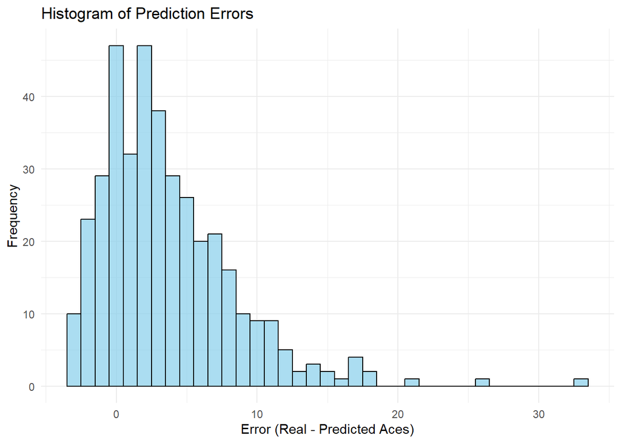

```r
#HISTOGRAM
ggplot(ATP_matches_predict, aes(x = error)) +
  geom_histogram(binwidth = 1, fill = "skyblue", color = "black", alpha = 0.7) +
  labs(title = "Histogram of Prediction Errors", x = "Error (Real - Predicted Aces)", y = "Frequency") +
  theme_minimal()
```

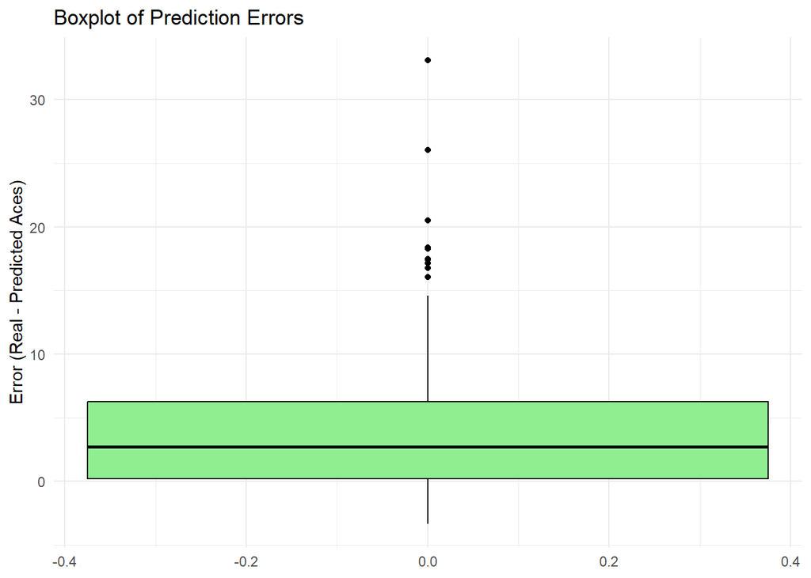

```r
#BOXPLOT
ggplot(ATP_matches_predict, aes(y = error)) +
  geom_boxplot(fill = "lightgreen", color = "black") +
  labs(title = "Boxplot of Prediction Errors", y = "Error (Real - Predicted Aces)") +
  theme_minimal()
```

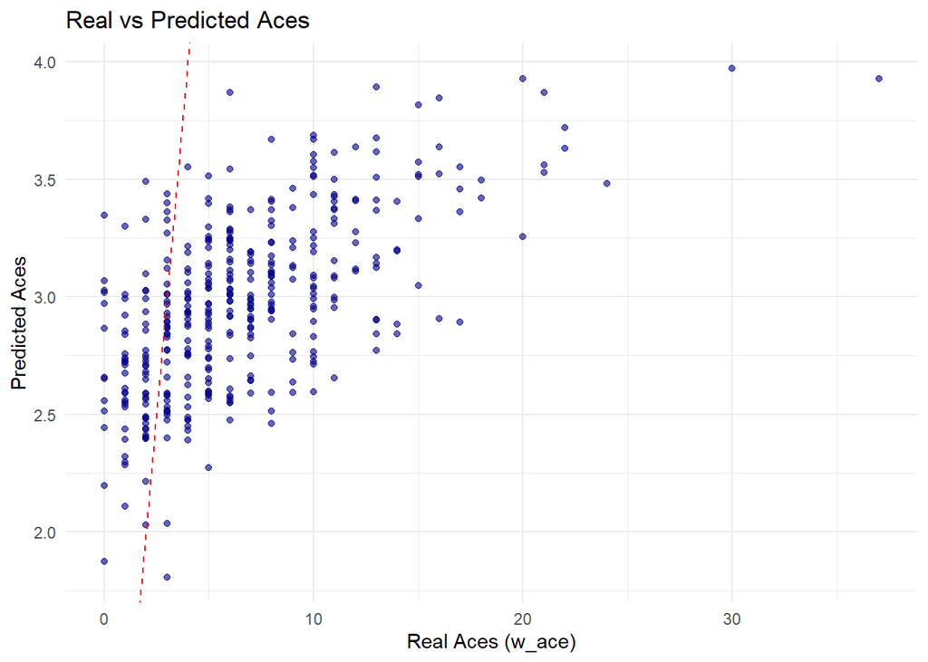

```r
# REAL VS PREDICTIONS
ggplot(ATP_matches_predict, aes(x = w_ace, y = predicted_ace)) +
  geom_point(color = "darkblue", alpha = 0.6) +
  geom_abline(slope = 1, intercept = 0, color = "red", linetype = "dashed") +
  labs(title = "Real vs Predicted Aces", x = "Real Aces (w_ace)", y = "Predicted Aces") +
  theme_minimal()
```

### 4.1.5 Predictive intervals

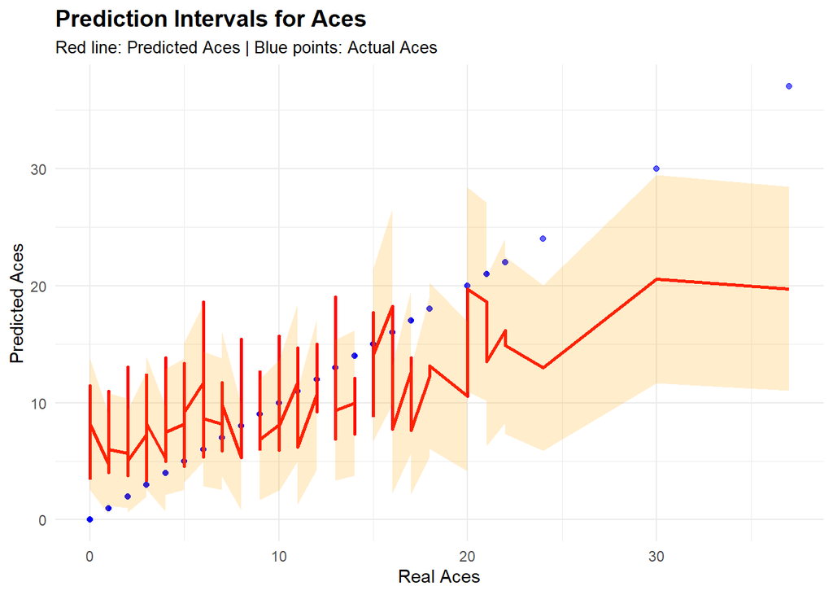

```r
ATP_matches_predict$predicted_ace <- predict(poisson_model, newdata = ATP_matches_predict, type = "response") + 1

ATP_matches_predict$error <- ATP_matches_predict$w_ace - ATP_matches_predict$predicted_ace
z <- qnorm(0.975)

ATP_matches_predict$Lower <- ATP_matches_predict$predicted_ace - z * sqrt(ATP_matches_predict$predicted_ace)
ATP_matches_predict$Upper <- ATP_matches_predict$predicted_ace + z * sqrt(ATP_matches_predict$predicted_ace)

ATP_matches_predict$Lower <- pmax(0, ATP_matches_predict$Lower)

library(ggplot2)

ggplot(ATP_matches_predict, aes(x = w_ace)) +
  geom_point(aes(y = w_ace), color = "blue", size = 1.5, alpha = 0.6) +
  geom_line(aes(y = predicted_ace), color = "red", size = 1) +
  geom_ribbon(aes(ymin = Lower, ymax = Upper), fill = "orange", alpha = 0.2) +
  labs(
    title = "Prediction Intervals for Aces",
    x = "Real Aces",
    y = "Predicted Aces",
    subtitle = "Red line: Predicted Aces | Blue points: Actual Aces"
  ) +
  theme_minimal() +
  theme(
    plot.title = element_text(size = 14, face = "bold"),
    plot.subtitle = element_text(size = 10)
  )
```

As we can observe, our model tends to fail primarily in extreme cases: when the player does not hit any aces or, conversely, when they achieve a significantly higher number than what is typically expected in a standard tennis match.

### 4.1.6 Benchmark

We will use a Benchmark model to assess the performance and quality of our predictive model. For this purpose, we will adopt the simplest benchmark approach, as previously applied, by using the mean value of the total Ace’s done by the winning player.

```r
# FILTER THE COLUMNS AND COMPUTE THE MEAN VALUE
ATP_matches_clean <- ATP_matches %>%
  filter(!is.na(w_ace))

# Calculate the mean value for 'w_ace'
benchmark <- mean(ATP_matches_clean$w_ace)

# Fit a regression model for the benchmark (mean)
benchFit <- lm(ATP_matches$w_ace ~ 1, data=ATP_matches)

# Make predictions using the benchmark model
pred.bench <- predict(benchFit, newdata=ATP_matches_predict)
```

```r
# Calculate R2 for the benchmark model
R2 <- 1 - (mean(abs(ATP_matches_clean$w_ace - pred.bench)) / mean(ATP_matches_clean$w_ace))
R2
```

```
## [1] 0.4381481
```

## 4.2 Model 4: Logistic regression for predicting match outcomes

We will now present the model that proves most effective for analyzing and predicting the outcome of a tennis match. Our goal is to create a model capable of predicting the winner of a match based on the characteristics of the two players involved and external conditions, such as the court surface.

To achieve this, we will consider variables such as player rankings, age, height, and others. Based on the initial analyses conducted earlier in this work, we concluded that variables like player ranking and service percentage are significant factors in determining victory or defeat. However, we still need to study how these factors interact and collectively influence the final outcome. Additionally, we aim to identify which factor has the greatest overall impact on match results.

### 4.2.1 Understanding the ‘target’ variable and the other variables

In the section **‘Variable Significance for Match Outcomes’**, we already conducted a detailed analysis of how certain variables influence the outcome of a match, specifically determining victory or defeat. Therefore, this step has already been addressed, and we can save time by leveraging the insights from that previous work.

In this model, our target variable will be a binary variable called **match_result**, which will determine the winner of the match. If **match_result** equals 1, it indicates that Player A won the match, and if it equals 0, it means Player B won the match. In our case, the player that appears first (the one labeled ‘winner_id’) will be labeled as Player A and the other player (the one labeled ‘loser_id’) will be labeled as Player B.

**Observation ( ¡VERY IMPORTANT! ):** In our case, the player labeled as *‘winner_name’* is always the one who wins the match, as our dataset is structured this way. Our target variable ‘*match_result*’ will take the value 1 if *‘winner_name’* wins and 0 if *‘loser_name’* wins.

It is important to note that in our training dataset, ‘*match_result’* will always take the value 1 because, by default, *’winner_name’* is the winning player. However, when making predictions, our model will treat *’winner_name’* as Player A and *’loser_name’* as Player B. The model will assign a value of 0 or 1 to the ’match_result’ variable based on its prediction.

Subsequently, we can evaluate the model’s error in predictions, as ‘match_result’ should technically always predict the value 1. This is because we are providing the model with the characteristics of Player A, who we already know is the winner, and Player B, who we know is the loser.

```r
#Create the variable 'match_result' (binary) but as explained always takes the value 1.
ATP_matches$match_result <- ifelse(ATP_matches$winner_id == ATP_matches$winner_id, 1, 0)
head(ATP_matches$match_result)
```

```
## [1] 1 1 1 1 1 1
```

### 4.2.2 Generalized linear model (Unbalanced dataset)

```r
# Variables we are going to consider
variables <- c("match_result", "winner_ht", "winner_age", "winner_rank", "w_1stIn", "w_svpt",
               "w_ace", "loser_ht", "loser_age", "loser_rank", "l_1stIn", "l_svpt", "l_ace",
               "surface", "winner_hand", "loser_hand", "tourney_level")

# Subset the dataset to include only the selected variables
numeric_data <- ATP_matches[, variables]

# Ensure categorical variables are treated as factors
numeric_data$surface <- as.factor(numeric_data$surface)
numeric_data$winner_hand <- as.factor(numeric_data$winner_hand)
numeric_data$loser_hand <- as.factor(numeric_data$loser_hand)
numeric_data$tourney_level <- as.factor(numeric_data$tourney_level)

# Check for and remove rows with missing values
numeric_data <- na.omit(numeric_data)

# Fit the logistic model
model <- glm(match_result ~ winner_ht + winner_age + winner_rank + w_1stIn + w_svpt + w_ace +
             loser_ht + loser_age + loser_rank + l_1stIn + l_svpt + l_ace + surface +
             winner_hand + loser_hand + tourney_level,
             data = numeric_data,
             family = binomial)

# Summary of the model
summary(model)
```

```
##
## Call:
## glm(formula = match_result ~ winner_ht + winner_age + winner_rank +
##     w_1stIn + w_svpt + w_ace + loser_ht + loser_age + loser_rank +
##     l_1stIn + l_svpt + l_ace + surface + winner_hand + loser_hand +
##     tourney_level, family = binomial, data = numeric_data)
##
## Coefficients:
##                  Estimate Std. Error z value Pr(>|z|)
## (Intercept)     2.657e+01  3.857e+05       0        1
## winner_ht      -1.735e-09  1.514e+03       0        1
## winner_age      3.747e-09  2.098e+03       0        1
## winner_rank    -1.917e-09  1.208e+02       0        1
## w_1stIn         4.966e-11  1.475e+03       0        1
## w_svpt          9.313e-10  1.151e+03       0        1
## w_ace          -1.612e-10  2.125e+03       0        1
## loser_ht       -7.761e-10  1.467e+03       0        1
## loser_age      -1.659e-10  2.088e+03       0        1
## loser_rank      5.923e-11  8.708e+01       0        1
## l_1stIn         7.603e-10  1.460e+03       0        1
## l_svpt         -1.015e-09  1.115e+03       0        1
## l_ace           6.335e-10  2.255e+03       0        1
## surfaceGrass   -1.794e-08  2.804e+04       0        1
## surfaceHard    -1.583e-08  1.976e+04       0        1
## winner_handR    2.078e-08  2.845e+04       0        1
## loser_handR    -2.255e-09  2.472e+04       0        1
## tourney_levelG -3.653e-08  2.869e+04       0        1
## tourney_levelM -2.005e-08  2.050e+04       0        1
##
## (Dispersion parameter for binomial family taken to be 1)
##
##     Null deviance: 0.0000e+00  on 1817  degrees of freedom
## Residual deviance: 1.0547e-08  on 1799  degrees of freedom
## AIC: 38
##
## Number of Fisher Scoring iterations: 25
```

**PROBLEM:**

Our model is not converging because the binary variable **is only taking one value,** making it impossible to compare. To fix this, I came up with the idea of treating the winner and loser variables as those of Player A and Player B in our training dataset as well. To do this, we will first define the variable *match_result*, which will randomly take a value of 0 or 1. If *match_result* takes the value 0, then the loser player will be considered Player A, and if *match_result* takes the value 1, then the winning player will be considered Player A. This approach makes sense because, in our tresting dataset, Player A will always be the winner of the match. Therefore, we can evaluate whether our prediction is correct (*match_result = 1*) or incorrect (*match_result = 0*).

### 4.2.3 Model adaptation balanced (final model)

The only remaining task is to adapt the data. If the *match_result* variable takes the value 0, then the loser will become Player A, and consequently, the characteristics of the loser player must be swapped with those of winner player to ensure consistency.

```r
set.seed(123)

# Define 'match_result' aleatory taking 0 or 1
ATP_matches$match_result <- sample(c(0, 1), size = nrow(ATP_matches), replace = TRUE)
```

The variable match_result now randomly determines which player is considered Player A and which is considered Player B. Additionally, based on the structure of our dataset, it also identifies the player who won the match (1 if Player A won and 0 if Player B won).

```r
# We randomize Player A and Player B based on the value of 'match_result'.
ATP_matches <- ATP_matches %>%
  mutate(
    player_A = ifelse(match_result == 0, loser_id, winner_id),
    player_B = ifelse(match_result == 0, winner_id, loser_id),

    player_A_name = ifelse(match_result == 0, loser_name, winner_name),
    player_B_name = ifelse(match_result == 0, winner_name, loser_name),

    player_A_ht = ifelse(match_result == 0, loser_ht, winner_ht),
    player_B_ht = ifelse(match_result == 0, winner_ht, loser_ht),

    player_A_age = ifelse(match_result == 0, loser_age, winner_age),
    player_B_age = ifelse(match_result == 0, winner_age, loser_age),

    player_A_rank = ifelse(match_result == 0, loser_rank, winner_rank),
    player_B_rank = ifelse(match_result == 0, winner_rank, loser_rank),

    player_A_hand = ifelse(match_result == 0, loser_hand, winner_hand),
    player_B_hand = ifelse(match_result == 0, winner_hand, loser_hand),

    player_A_1stIn = ifelse(match_result == 0, l_1stIn, w_1stIn),
    player_B_1stIn = ifelse(match_result == 0, w_1stIn, l_1stIn),

    player_A_svpt = ifelse(match_result == 0, l_svpt, w_svpt),
    player_B_svpt = ifelse(match_result == 0, w_svpt, l_svpt),

    player_A_ace = ifelse(match_result == 0, l_ace, w_ace),
    player_B_ace = ifelse(match_result == 0, w_ace, l_ace),

    player_A_1stWon = ifelse(match_result == 0, l_1stWon, w_1stWon),
    player_B_1stWon = ifelse(match_result == 0, w_1stWon, l_1stWon)
  )
```

```r
# VARIABLES OF THE MODEL
variables <- c("match_result", "player_A_ht", "player_A_rank",
               "player_A_ace", "player_B_ht", "player_B_rank"
               , "player_B_ace", "surface",'player_A_1stIn','player_B_1stIn')

numeric_data <- ATP_matches[, variables]

# LOGISTIC REGRESSION
model <- glm(match_result ~ ., data = numeric_data, family = binomial)

summary(model)
```

```
##
## Call:
## glm(formula = match_result ~ ., family = binomial, data = numeric_data)
##
## Coefficients:
##                  Estimate Std. Error z value Pr(>|z|)
## (Intercept)     2.4429714  2.1852603   1.118   0.2636
## player_A_ht    -0.0163881  0.0084368  -1.942   0.0521 .
## player_A_rank  -0.0038295  0.0007058  -5.426 5.77e-08 ***
## player_A_ace    0.0915616  0.0134799   6.792 1.10e-11 ***
## player_B_ht     0.0020587  0.0089715   0.229   0.8185
## player_B_rank   0.0048062  0.0008270   5.812 6.18e-09 ***
## player_B_ace   -0.0936910  0.0133683  -7.008 2.41e-12 ***
## surfaceGrass    0.0531818  0.1618838   0.329   0.7425
## surfaceHard     0.0448061  0.1162211   0.386   0.6998
## player_A_1stIn  0.0040343  0.0046226   0.873   0.3828
## player_B_1stIn -0.0013431  0.0048176  -0.279   0.7804
## ---
## Signif. codes:  0 '***' 0.001 '**' 0.01 '*' 0.05 '.' 0.1 ' ' 1
##
## (Dispersion parameter for binomial family taken to be 1)
##
##     Null deviance: 2519.4  on 1817  degrees of freedom
## Residual deviance: 2323.5  on 1807  degrees of freedom
##   (348 observations deleted due to missingness)
## AIC: 2345.5
##
## Number of Fisher Scoring iterations: 4
```

**Explanation** As we can observe, the most influential variables to consider are those related to ranking (as it represents a player’s current level) and those associated with serving, such as the number of aces, which reflects the ‘free points’ a player can win without needing to play out the rally.

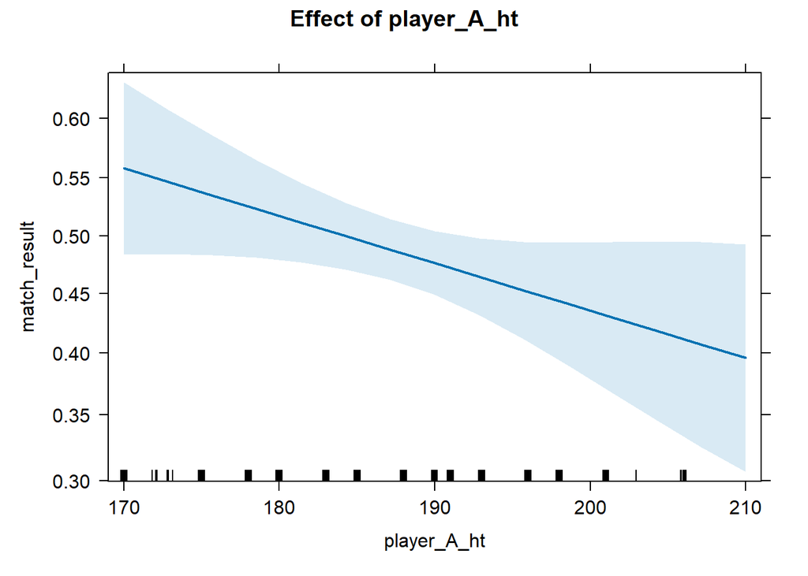

```r
# Individual effect for player_A_ht
effect_player_A_ht <- effect("player_A_ht", model)
plot(effect_player_A_ht, main = "Effect of player_A_ht")
```

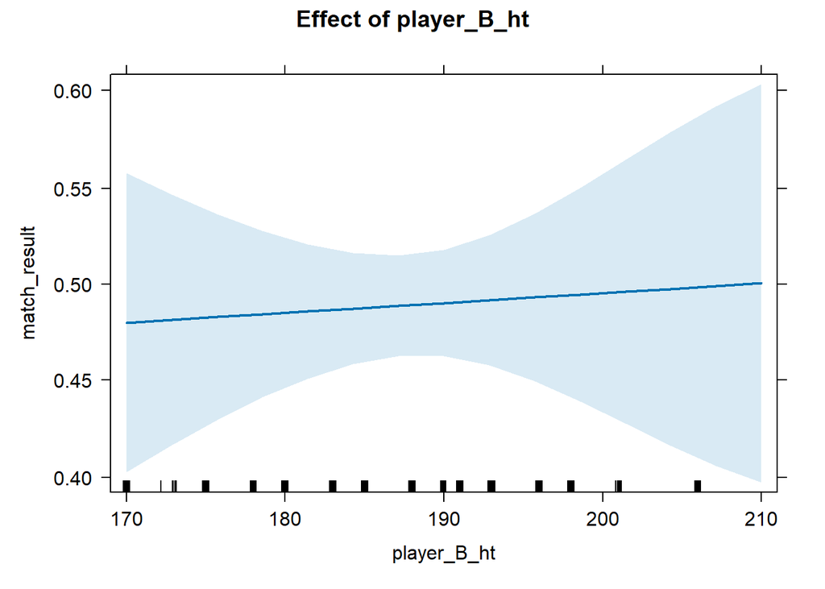

```r
# Individual effect for player_B_ht
effect_player_B_ht <- effect("player_B_ht", model)
plot(effect_player_B_ht, main = "Effect of player_B_ht")
```

As we can observe, although height generally favors a stronger serve, the players who tend to win more often are those who are shorter. This is because shorter players usually exhibit better court mobility, allowing them to win crucial and contested points.

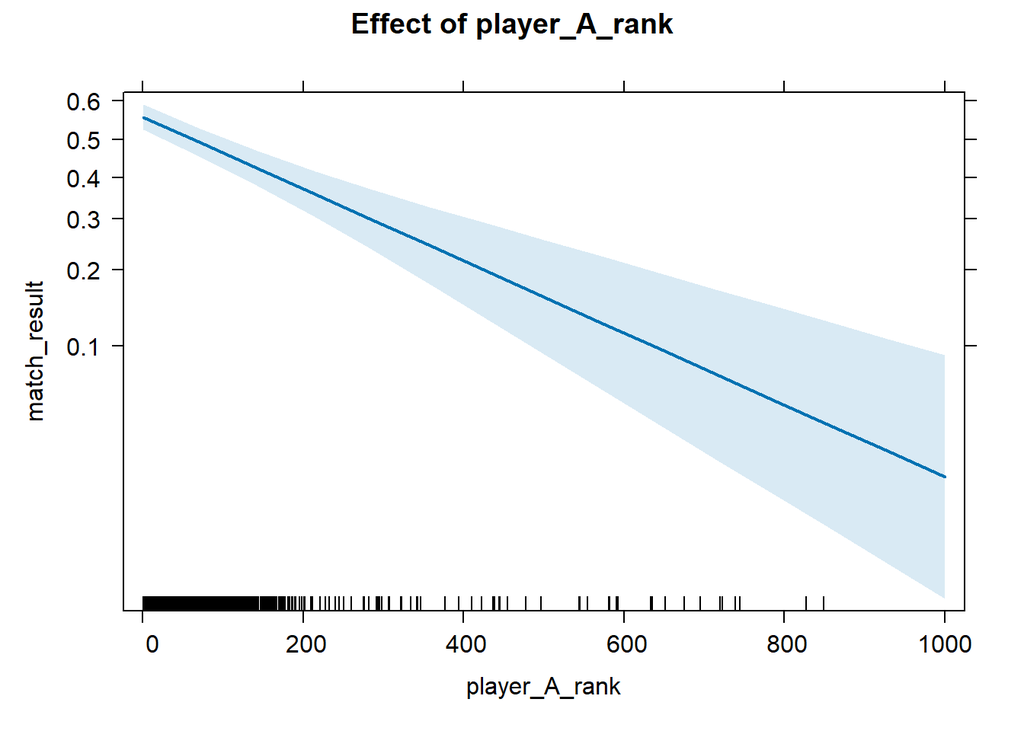

```r
# Individual effect for player_A_rank
effect_player_A_rank <- effect("player_A_rank", model)
plot(effect_player_A_rank, main = "Effect of player_A_rank")
```

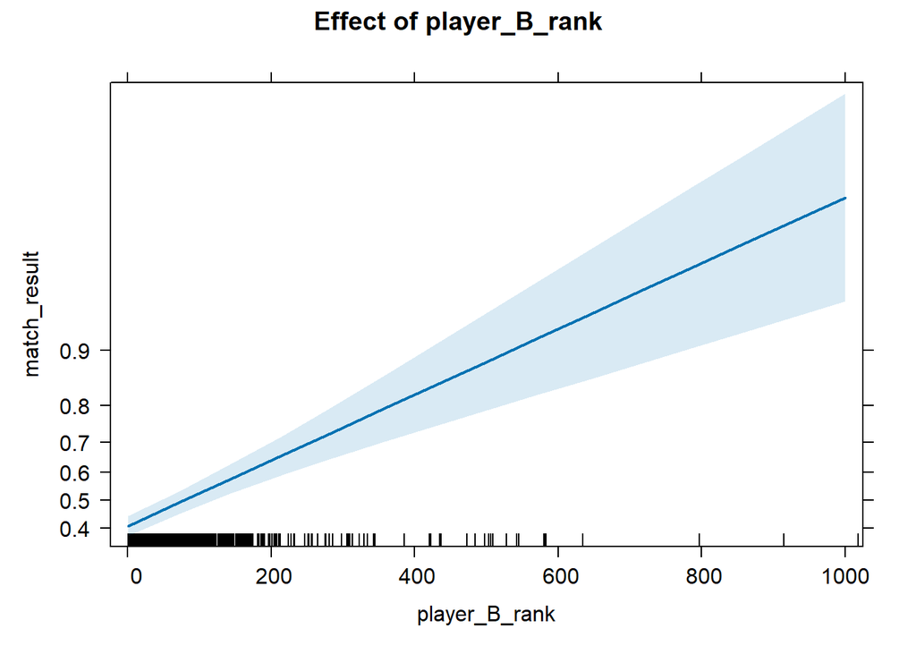

```r
# Individual effect for player_B_rank
effect_player_B_rank <- effect("player_B_rank", model)
plot(effect_player_B_rank, main = "Effect of player_B_rank")
```

As we can observe, ranking plays a fundamental role: the better Player A’s ranking, the closer the prediction value gets to 1, indicating that Player A is likely to win. Similarly, the better Player B’s ranking, the closer the prediction value gets to 0, signaling that Player B is the likely winner of the match.

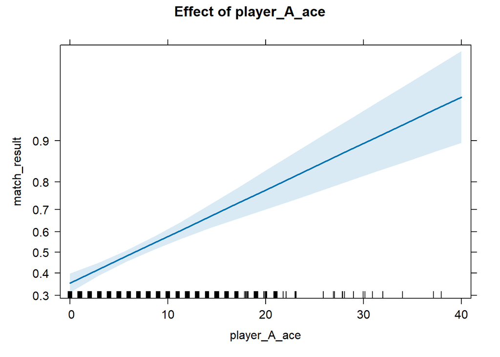

```r
# Individual effect for player_A_ace
effect_player_A_ace <- effect("player_A_ace", model)
plot(effect_player_A_ace, main = "Effect of player_A_ace")
```

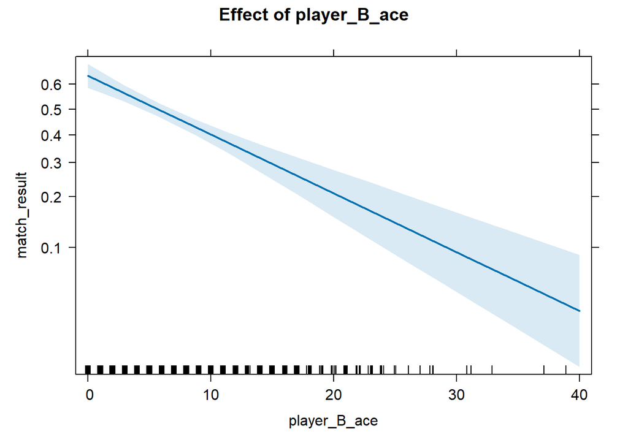

```r
# Individual effect for player_B_ace
effect_player_B_ace <- effect("player_B_ace", model)
plot(effect_player_B_ace, main = "Effect of player_B_ace")
```

We observe a similar pattern with the number of aces: the more aces Player A hits, the closer the prediction value gets to 1, indicating that Player A is likely to win the match. The same applies to Player B, where more aces bring the prediction value closer to 0, suggesting a victory for Player B.

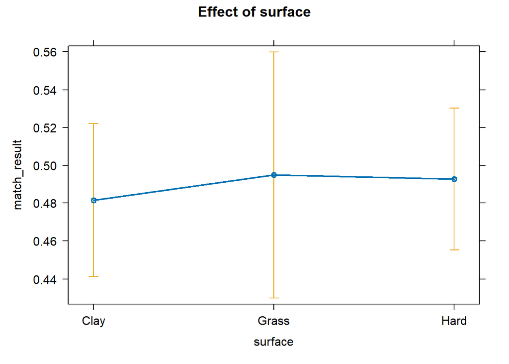

```r
# Individual effect for surface
effect_surface <- effect("surface", model)
plot(effect_surface, main = "Effect of surface")
```

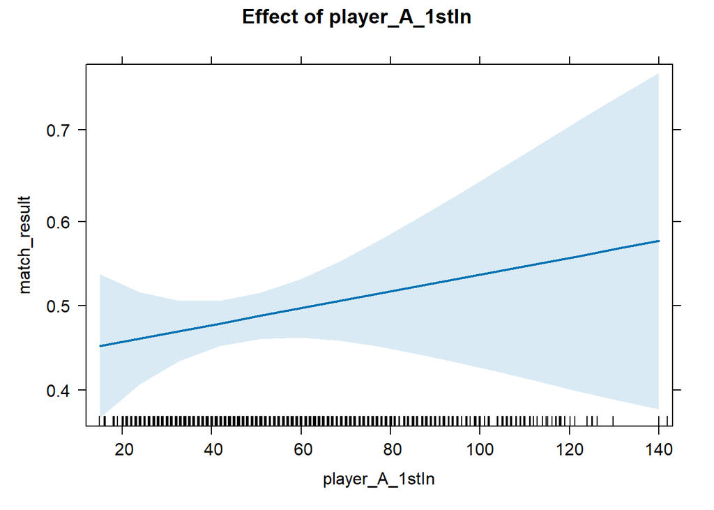

```r
# Individual effect for player_A_1stIn
effect_player_A_1stIn <- effect("player_A_1stIn", model)
plot(effect_player_A_1stIn, main = "Effect of player_A_1stIn")
```

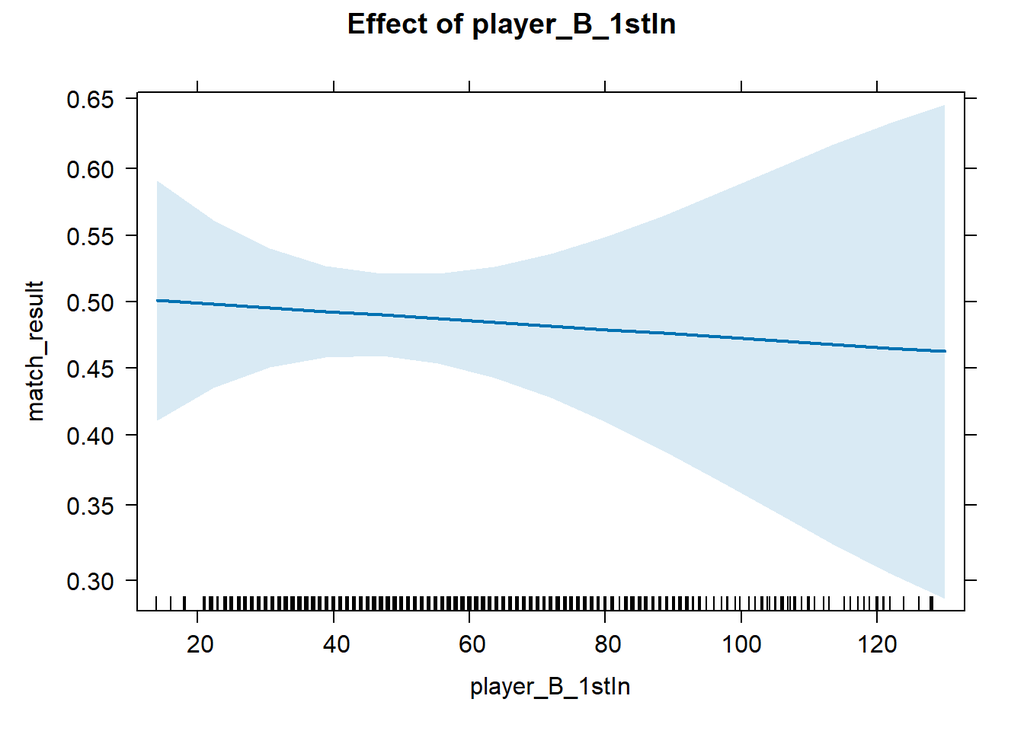

```r
# Individual effect for player_B_1stIn
effect_player_B_1stIn <- effect("player_B_1stIn", model)
plot(effect_player_B_1stIn, main = "Effect of player_B_1stIn")
```

### 4.2.4 Prediction

Since in our test dataset Player A is always the player identified by *‘winner_id’*, our *match_result* variable will always take the value 1, as Player A will always be the winner.

```r
#Data cleaning
ATP_matches_predict$match_result <- 1
```

```r
ATP_matches_predict <- ATP_matches_predict %>%
  mutate(
    player_A = winner_id,
    player_B = loser_id,

    player_A_name = winner_name,
    player_B_name = loser_name,

    player_A_ht = winner_ht,
    player_B_ht = loser_ht,

    player_A_age = winner_age,
    player_B_age = loser_age,

    player_A_rank = winner_rank,
    player_B_rank = loser_rank,

    player_A_hand = winner_hand,
    player_B_hand = loser_hand,

    player_A_1stIn = w_1stIn,
    player_B_1stIn = l_1stIn,

    player_A_svpt = w_svpt,
    player_B_svpt = l_svpt,

    player_A_ace = w_ace,
    player_B_ace = l_ace,

    player_A_1stWon = w_1stWon,
    player_B_1stWon = l_1stWon
  )
```

```r
# PREDICTION
ATP_matches_predict$predicted_result <- predict(model, newdata = ATP_matches_predict, type = "response")

ATP_matches_predict$predicted_winner <- ifelse(ATP_matches_predict$predicted_result > 0.5, 1, 0)

head(ATP_matches_predict$predicted_winner)
```

```
## [1] 1 0 0 1 0 1
```

### 4.2.5 Accuracy of the model

```r
# Count the number of times we have 0, 1 and NA
count_1 <- sum(ATP_matches_predict$predicted_winner == 1, na.rm = TRUE)
count_0 <- sum(ATP_matches_predict$predicted_winner == 0, na.rm = TRUE)
count_na <- sum(is.na(ATP_matches_predict$predicted_winner))

# Total observations
total_non_na <- sum(!is.na(ATP_matches_predict$predicted_winner))

#Precision
precision <- count_1 / total_non_na

precision
```

```
## [1] 0.6055556
```

Our accuracy is 60%, meaning that for a given match, we can predict the result with a 0.6 probability of success. Now, we will compare this with a benchmark model to assess whether this is a good analysis or, on the contrary, if our model is not capable of estimating with greater precision than simply predicting with the mean.

### 4.2.6 Benchmark

```r
# COUNT 1'S
count_matches_result_1 <- sum(ATP_matches$match_result == 1)

total_matches <- nrow(ATP_matches)

# PROPORTION
proportion_match_result_1 <- count_matches_result_1 / total_matches

proportion_match_result_1
```

```
## [1] 0.4879963
```

In this case, predicting with the mean would give us an accuracy of less than 50%. This indicates that we have gained a 10% improvement in probability compared to our benchmark model, which is a notable achievement. Therefore, we can confidently state that our model is explanatory.